# Checking PSA data vs Texture Codes

Lauren O’Brien

2019-11-01

Field texture measures the behaviour of a small volume of soil at field capacity. The Yellow Book notes correctly that texture doesn’t map neatly to PSA (which notably excludes +2mm size fractions and ignores the influence of organic matter, sesquioxides, etc on soil physical behaviour). However, texture codes are qualitatively defined using references to particle size fractions and are roughly mapped to the texture triangle, so PSA data can potentially be used to sanity-check these rankings. That said, not all PSA data makes sense next to texture codes, for instance there are some sand group PSAs in SALI with 60% clay.

While the Yellow Book says not to adjust texture codes in the face of PSA data, that’s a sentence that doesn’t account for actual errors in a database. Its trying to make the point that PSA measurements and physical soil behaviour aren’t necessarily tightly linked (e.g. in subplastic soils) and that the surveyor should trust their perceptions.

```r
options(stringsAsFactors = FALSE, scipen = 999)
library(sf)            # vector data IO and processing
library(DBI)           # database interface
library(ROracle)       # Oracle database drivers
library(getPass)       # password management
library(units)         # for working with unit-attributed data
library(tidyverse)     # general data manipulation and display
library(ggtern)        # ternary ggplots

Sys.setenv(
  'TNS_ADMIN'   = file.path('C:', 'Users', Sys.getenv('USERNAME'), 'Oracle'),
  'ORACLE_HOME' = 'C:/Program Files/Oracle Instant Client'
  )
SALI <- dbConnect(dbDriver('Oracle'),
                  username = 'obrienle',
                  password = getPass(),
                  dbname   = 'sispda',
                  host     = 'ex02client01',
                  port     = 1521)

if(!dir.exists(file.path(getwd(), 'SALI_DATA'))) {
  dir.create(file.path(getwd(), 'SALI_DATA'))
}

if(!dir.exists(file.path(getwd(), 'DERIVED_DATA'))) {
  dir.create(file.path(getwd(), 'DERIVED_DATA'))
}
```

So, now to extract PSA data from SALI and generate stats for Clay, Silt, Fine Sand, and Coarse Sand fractions. There’s data in SALI from multiple PSA lab methods, but by far the bulk of it is in the four codes below so I’ll focus on that for now.

```r
tex_psa <-
  dbGetQuery(SALI,
  "select project_code, site_id, obs_no, horizon_no, sample_no, texture_code || texture_qualifier as texture,
     lab_meth_code, numeric_value, raw_value, result_status
   from sit_horizons
   left outer join sit_samples using (project_code, site_id, obs_no, horizon_no)
   left outer join
     (select * from sit_lab_results
       where lab_meth_code in('2Z2_Clay', '2Z2_Silt', '2Z2_FS', '2Z2_CS')) psa
         using(project_code, site_id, obs_no, horizon_no, sample_no)
   where result_status in ('A', 'BQ')
   order by project_code, site_id, obs_no, horizon_no, sample_no")
```

113784 analytical results to mess about with.

There’s a few things to tidy up.

```r
# r doesn't like variables starting with numbers too much
tex_psa$LAB_METH_CODE <- gsub('2Z2_', 'PSA_', tex_psa$LAB_METH_CODE)
```

All the samples with numeric value NA and raw value 0 can be set to 0.

```r
tex_psa$NUMERIC_VALUE[which(tex_psa$RAW_VALUE == 0 &
                              is.na(tex_psa$NUMERIC_VALUE))] <- 0
```

Same goes for BQ samples where raw value is 0 and numeric value disagrees, e.g. samples in CBW 288.

```r
tex_psa$NUMERIC_VALUE[which(tex_psa$RAW_VALUE == 0 & tex_psa$NUMERIC_VALUE > 10 &
                             tex_psa$RESULT_STATUS == 'BQ')] <- 0
```

```r
tex_psa$NUMERIC_VALUE[which(tex_psa$NUMERIC_VALUE == 173)] <- 0
```

Other errors won’t be apparent until the data is wide-formatted and total PSA values checked. Any that don’t add up to between 95 and 105% are suspect.

```r
tex_psa_totals <- tex_psa %>%
  dplyr::select(-RAW_VALUE, -RESULT_STATUS) %>%
  group_by(PROJECT_CODE, SITE_ID, OBS_NO, HORIZON_NO, SAMPLE_NO, TEXTURE) %>%
  summarise(TOTAL_PSA = sum(NUMERIC_VALUE, na.rm = TRUE),
            N_COMP    = sum(!is.na(NUMERIC_VALUE)))

tex_psa_wide <- tex_psa %>%
  dplyr::select(-RAW_VALUE, -RESULT_STATUS) %>%
  pivot_wider(names_from = LAB_METH_CODE, values_from = NUMERIC_VALUE)

tex_psa_wide <- left_join(tex_psa_wide, tex_psa_totals,
                          by = c('PROJECT_CODE' , 'SITE_ID', 'OBS_NO',
                                 'HORIZON_NO', 'SAMPLE_NO', 'TEXTURE'))
```

1346 results total over 105%. Its immediately apparent that many have duplicated data in two PSA size fractions, e.g.:

```r
dplyr::filter(tex_psa_wide, TOTAL_PSA > 105) %>%
  arrange(desc(TOTAL_PSA)) %>%
  select(TEXTURE, matches('^PSA_'), TOTAL_PSA) %>%
           head()
```

```
## # A tibble: 6 x 6
##   TEXTURE PSA_CS PSA_Clay PSA_FS PSA_Silt TOTAL_PSA
##   <chr>    <dbl>    <dbl>  <dbl>    <dbl>     <dbl>
## 1 <NA>        71        4     61       35       171
## 2 LS          14        5     71       71       161
## 3 LS          14        4     71       71       160
## 4 LS          16        4     70       70       160
## 5 LS          16        7     67       67       157
## 6 FSL         12        7     68       68       155
```

These can only be resolved manually with reference to full descriptions, and even then it can be hard to tell what to do. For the purposes of this exercise, I’m just going to filter out anything that totals over 105%.

A similar issue exists for samples that total less than 95% (n = 775):

```r
dplyr::filter(tex_psa_wide, TOTAL_PSA < 95) %>%
  select(TEXTURE, matches('^PSA_'), TOTAL_PSA) %>%
           head()
```

```
## # A tibble: 6 x 6
##   TEXTURE PSA_CS PSA_Clay PSA_FS PSA_Silt TOTAL_PSA
##   <chr>    <dbl>    <dbl>  <dbl>    <dbl>     <dbl>
## 1 CL         0.5       60      5       29      94.5
## 2 LC+       36         30     20        8      94
## 3 SCL       37         13     29       14      93
## 4 CL        NA         13     25       19      57
## 5 HC        10         62     13        7      92
## 6 SC        61          2     18        8      89
```

Some are missing data (particularly in the sand fractions), a few add to 0, and the rest are just a bit weird. They can go as well (note: this data is already in a queue to be corrected, behind a long line of other tasks).

Along with removing samples from horizons without a texture code, and samples with too many missing components, and a couple of dud texture codes,

```r
tex_psa_clean <- tex_psa_wide %>%
  dplyr::filter(TOTAL_PSA <= 105) %>%
  dplyr::filter(TOTAL_PSA >= 95) %>%
  dplyr::filter(N_COMP > 2) %>%
  dplyr::filter(!is.na(TEXTURE)) %>%
  dplyr::filter(!(TEXTURE %in% c('-', '+'))) %>%
  mutate_at(vars(matches('^PSA_')), replace_na, 0)

# per above, remaining NAs are almost certainly legit 0s e.g. no clay measured
# on a coarse sand texture sample
```

25023 data points remain. Good enough to go on with.

It’s still kind of hard to rank this data. McNeill (2018) contains some treatments for mapping ternary PSA data back to a cartesian space, removing the structural correlation that comes from all the fractions having to add to 100%. These might help. A ‘Not_Clay’ percentage may also be useful.

```r
tex_psa_norm <- tex_psa_clean %>%
  # first normalise
  mutate_at(vars(matches('^PSA_')), function(x)  {x / .$TOTAL_PSA * 100 } ) %>%
  rowwise() %>%
  mutate(Not_Clay = sum(c(PSA_Silt, PSA_FS, PSA_CS)),
         TOTAL_PSA = sum(c(PSA_Clay, PSA_Silt, PSA_FS, PSA_CS))) %>%
  ungroup() %>%
  mutate_at(vars(matches('^PSA_'), TOTAL_PSA), round) %>%
  select(-N_COMP) %>%
  # now calc w1 and w2
  rowwise() %>%
  mutate(W1 = (2 * sum(c(PSA_FS, PSA_CS))) - PSA_Silt - PSA_Clay,
         W2 = PSA_Silt - PSA_Clay) %>%
  ungroup() %>%
  arrange(W1, W2)
```

With this dataset, some summary statistics can be calculated by texture code:

```r
texcode_stats <- tex_psa_norm %>%
  group_by(TEXTURE) %>%
  summarise(Q16_CLAY = round(quantile(PSA_Clay, 0.159, na.rm = TRUE), 1),
            MED_CLAY = round(median(PSA_Clay, na.rm = TRUE), 1),
            Q84_CLAY = round(quantile(PSA_Clay, 0.841, na.rm = TRUE), 1),
            Q16_SILT = round(quantile(PSA_Silt, 0.159, na.rm = TRUE), 1),
            MED_SILT = round(median(PSA_Silt, na.rm = TRUE), 1),
            Q84_SILT = round(quantile(PSA_Silt, 0.841, na.rm = TRUE), 1),
            Q16_FSND = round(quantile(PSA_FS, 0.159, na.rm = TRUE), 1),
            MED_FSND = round(median(PSA_FS, na.rm = TRUE), 1),
            Q84_FSND = round(quantile(PSA_FS, 0.841, na.rm = TRUE), 1),
            Q16_CSND = round(quantile(PSA_CS, 0.159, na.rm = TRUE), 1),
            MED_CSND = round(median(PSA_CS, na.rm = TRUE), 1),
            Q84_CSND = round(quantile(PSA_CS, 0.841, na.rm = TRUE), 1),
            Q16_NCLY = round(quantile(Not_Clay, 0.159, na.rm = TRUE), 1),
            MED_NCLY = round(median(Not_Clay, na.rm = TRUE), 1),
            Q84_NCLY = round(quantile(Not_Clay, 0.841, na.rm = TRUE), 1),
            Q16_W1   = round(quantile(W1, 0.159, na.rm = TRUE)),
            MED_W1   = round(median(W1, na.rm = TRUE)),
            Q84_W1   = round(quantile(W1, 0.841, na.rm = TRUE)),
            Q16_W2   = round(quantile(W2, 0.159, na.rm = TRUE)),
            MED_W2   = round(median(W2, na.rm = TRUE)),
            Q84_W2   = round(quantile(W2, 0.841, na.rm = TRUE)),
            N_CLAY   = sum(!is.na(PSA_Clay)),
            N_SILT   = sum(!is.na(PSA_Silt)),
            N_FSND   = sum(!is.na(PSA_FS)),
            N_CSND   = sum(!is.na(PSA_CS))) %>%
  # rank sandiest to clayeyest
  arrange(desc(MED_NCLY), MED_CLAY)

stats_simple <- texcode_stats %>%
  dplyr::select(TEXTURE, MED_CLAY, MED_SILT, MED_FSND, MED_CSND,
                MED_NCLY, MED_W1, MED_W2, N_CLAY) %>%
  mutate(MED_SUM = rowSums(select(., MED_CLAY, MED_NCLY)))

write_csv(texcode_stats, file.path(getwd(), 'SALI_DATA', 'tex_psa_wide.csv'))
write_csv(stats_simple, file.path(getwd(), 'SALI_DATA', 'tex_psa_simple.csv'))
```

A ternary plot for each texture code should be useful.

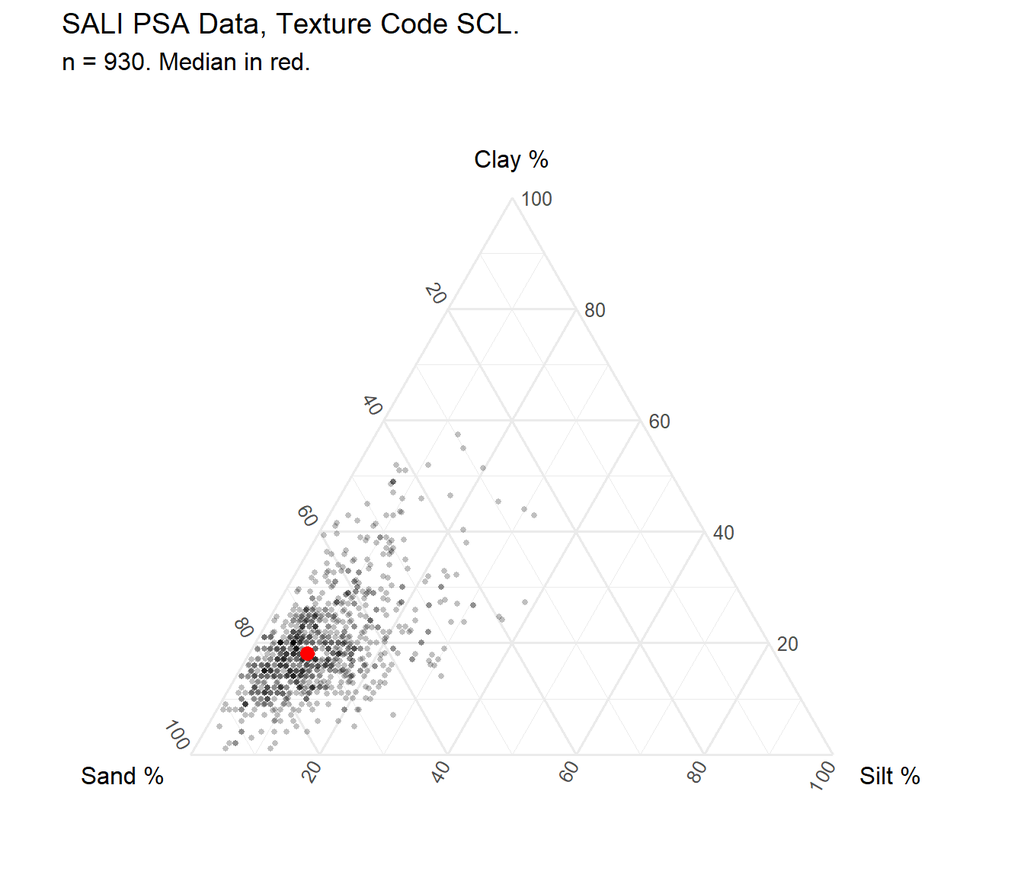

```r
codes <- sort(unique(texcode_stats$TEXTURE))

psa_plots <- lapply(codes, function(x) {

  texs <- dplyr::filter(tex_psa_norm, TEXTURE == x) %>%
    rowwise() %>%
    mutate(SAND = sum(c(PSA_CS, PSA_FS), na.rm = TRUE)) %>%
   ungroup()

  nt <- nrow(texs)
  med_tex <- summarise_all(texs, median)

  ggtern(data = texs,
       aes(y = PSA_Clay, z = PSA_Silt, x = SAND), colour = 'grey50',
       show.legend = FALSE) +
  geom_point(size = 1, shape = 16, alpha = 0.25) +
  geom_point(data = med_tex, col = 'red', size = 3, shape = 16) +
  ggtitle(paste0('SALI PSA Data, Texture Code ', x, '.'),
          subtitle = paste0('n = ', nt, '. Median in red.')) +
  labs(x = "Sand %", y = 'Clay %', z = 'Silt %') +
  theme_minimal()

})
names(psa_plots) <- codes

# e.g.
psa_plots[['SCL']]
```

```r
saveRDS(psa_plots, file.path(getwd(), 'DERIVED_DATA', 'PSA_PLOTS.rds' ))
```

Plot medians by rank too:

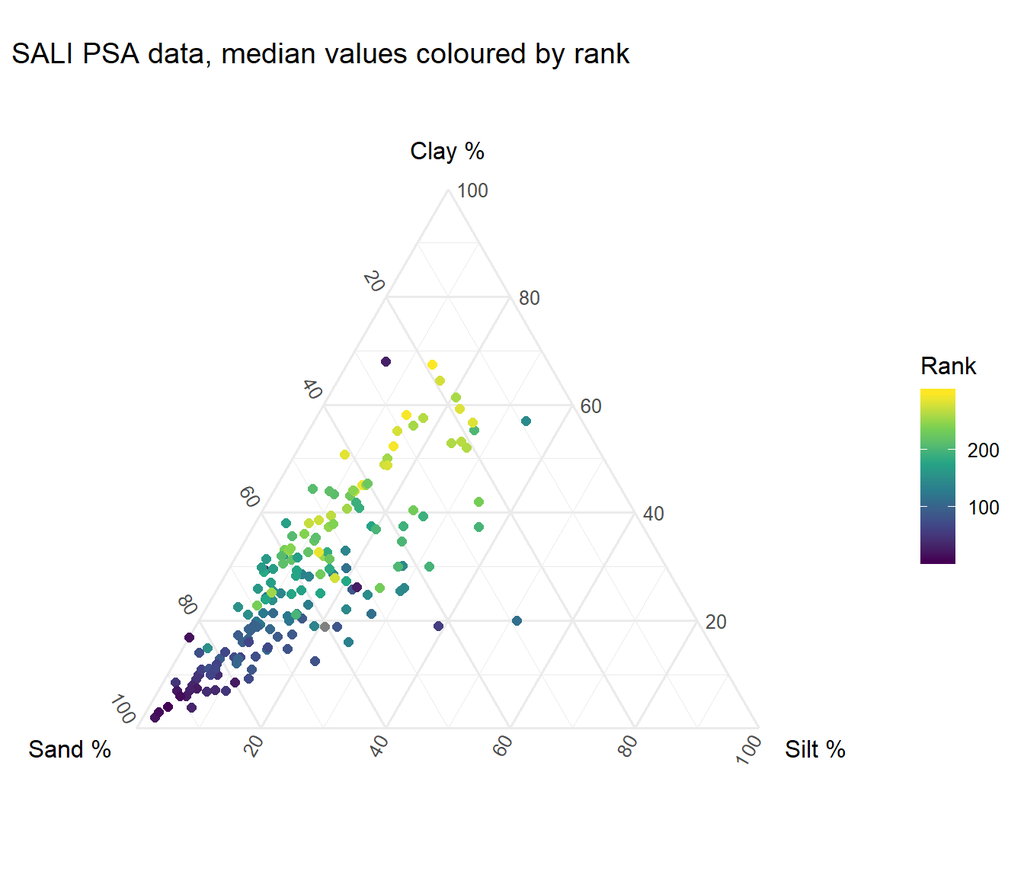

```r
tex_ranks <-
  read_csv(file.path(getwd(), 'helpers', 'SALI_TEXTURES_RANKED_2.csv'))

stplot <- tex_psa_norm %>%
  rowwise() %>%
  mutate(PSA_Sand = sum(c(PSA_CS, PSA_FS), na.rm = TRUE)) %>%
  ungroup() %>%
  select(-PROJECT_CODE, -SITE_ID, -OBS_NO, -HORIZON_NO, -SAMPLE_NO) %>%
  group_by(TEXTURE) %>%
  summarise_if(is.numeric, median, na.rm = TRUE) %>%
  left_join(., tex_ranks[, c('TEXTURE', 'GROUP_1', 'GROUP_2', 'GROUP_3',
                             'GROUP_4', 'FINAL_RANK')], by = 'TEXTURE')

ggtern(data = stplot,
       aes(y = PSA_Clay, z = PSA_Silt, x = PSA_Sand, colour = FINAL_RANK),
       show.legend = FALSE) +
  geom_point(size = 2, shape = 16) +
  scale_colour_viridis_c() +
  ggtitle('SALI PSA data, median values coloured by rank') +
  labs(x = "Sand %", y = 'Clay %', z = 'Silt %', colour = 'Rank') +
  theme_minimal()
```

```r
# couple of outliers:
filter(stplot, FINAL_RANK < 150 & PSA_Clay > 50 )
```

```
## # A tibble: 2 x 15
##   TEXTURE PSA_CS PSA_Clay PSA_FS PSA_Silt TOTAL_PSA Not_Clay    W1    W2
##   <chr>    <dbl>    <dbl>  <dbl>    <dbl>     <dbl>    <dbl> <dbl> <dbl>
## 1 LMS         22       68      4        6       100     32.2   -22   -62
## 2 ZCLI         1       57      8       34       100     42.8   -73   -23
## # ... with 6 more variables: PSA_Sand <dbl>, GROUP_1 <chr>, GROUP_2 <chr>,
## #   GROUP_3 <chr>, GROUP_4 <chr>, FINAL_RANK <dbl>
```

```r
# LMS is a typo for LMC I'm p sure - have emailed about it
# ZCLI is on CQA 208 - marine mud, with MC either side and no discont. Maybe
# a typo for ZLCI, or an underestimate thanks to being saturated.
# good enough, pitter patter
```